# Bellabeat

Manu Shyam

2023-12-29

# Introduction

This case study is for the Google & Coursera Data Analytics Certificate. Bellabeat is a high-tech manufacture of fitness devices for women. The primary focus of these devices are to track and give analysis on sleep, fitness, and other health related patterns.

Some of these primary products include:

- Bellabeat App - Connects to other Bellabeat devices to provide users information on their health, sleep cycles, fitness, mindfulness habits, and more.
- Leaf - This is a wellness tracker that can be worn as a bracelet, necklace, or clip. This is the classic fitness device in the Bellabeat line.
- Time - This wellness watch combines the aesthetic as a natural timepiece while having the smart technology capabilities to track users sleep patterns, steps, and stress. Connects to the Bellabeat App to give insights to your wellness.
- Spring - This is a water bottle that tracks your daily water intake using smart technology to ensure you are appropriately hydrated throughout the day. The bottle also connects to the Bellabeat App.
- Bellabeat membership: Bellabeat also offers a subscription-based membership program for users. Membership gives users 24/7 access to fully personalized guidance on nutrition, activity, sleep, health and beauty, and mindfulness based on their lifestyle and goals.

# 1. ASK

# Stakeholders

- Urška Sršen: Bellabeat’s cofounder and Chief Creative Officer
- Sando Mur: Mathematician and Bellabeat’s cofounder; key member of the Bellabeat executive team
- Bellabeat marketing analytics team: A team of data analysts responsible for collecting, analyzing, and reporting data that helps guide Bellabeat’s marketing strategy.

## More About the Company

Urška Sršen and Sando Mur founded Bellabeat, a high-tech company that manufactures health-focused smart products. Sršen used her background as an artist to develop beautifully designed technology that informs and inspires women around the world. Collecting data on activity, sleep, stress, and reproductive health has allowed Bellabeat to empower women with knowledge about their own health and habits. Since it was founded in 2013, Bellabeat has grown rapidly and quickly positioned itself as a tech-driven wellness company for women.

## Business Task

Questions to Consider during the analysis

1. What are some trends in smart device usage?
2. How could these trends apply to Bellabeat customers?
3. How could these trends help influence Bellabeat marketing strategy?

# 2. PREPARE

## Loading the Packages

First, I loaded the necessary packages to analyze the datasets.

```r
library(tidyverse)
```

```r
library(dplyr)
library(ggplot2)
```

## Loading the Dataset

Then, I loaded the dataset, which consists of 18 files, including daily, hourly and minute wise data. Daily activity, daily intensities, hourly intensities, sleep and weight log files are in wide data format, while other daily and hourly files are structured in the narrow data format. Minute files are available in both wide and narrow formats. I loaded the narrow format since it is more easy to use.

```r
dailyIntensities_merged <- read_csv("Fitbit_data/Fitabase Data 4.12.16-5.12.16/dailyIntensities_merged.csv")
dailySteps_merged <- read_csv("Fitbit_data/Fitabase Data 4.12.16-5.12.16/dailySteps_merged.csv")
dailyActivity_merged <- read_csv("Fitbit_data/Fitabase Data 4.12.16-5.12.16/dailyActivity_merged.csv")
sleepDay_merged <- read_csv("Fitbit_data/Fitabase Data 4.12.16-5.12.16/sleepDay_merged.csv")
```

Now let’s preview the data frames

```r
head(dailyActivity_merged)
```

```
## # A tibble: 6 × 15
##           Id ActivityDate TotalSteps TotalDistance TrackerDistance
##        <dbl> <chr>             <dbl>         <dbl>           <dbl>
## 1 1503960366 4/12/2016         13162          8.5             8.5
## 2 1503960366 4/13/2016         10735          6.97            6.97
## 3 1503960366 4/14/2016         10460          6.74            6.74
## 4 1503960366 4/15/2016          9762          6.28            6.28
## 5 1503960366 4/16/2016         12669          8.16            8.16
## 6 1503960366 4/17/2016          9705          6.48            6.48
## # ℹ 10 more variables: LoggedActivitiesDistance <dbl>,
## #   VeryActiveDistance <dbl>, ModeratelyActiveDistance <dbl>,
## #   LightActiveDistance <dbl>, SedentaryActiveDistance <dbl>,
## #   VeryActiveMinutes <dbl>, FairlyActiveMinutes <dbl>,
## #   LightlyActiveMinutes <dbl>, SedentaryMinutes <dbl>, Calories <dbl>
```

```r
head(dailyIntensities_merged)
```

```
## # A tibble: 6 × 10
##         Id ActivityDay SedentaryMinutes LightlyActiveMinutes FairlyActiveMinutes
##      <dbl> <chr>                  <dbl>                <dbl>               <dbl>
## 1   1.50e9 4/12/2016                728                  328                  13
## 2   1.50e9 4/13/2016                776                  217                  19
## 3   1.50e9 4/14/2016               1218                  181                  11
## 4   1.50e9 4/15/2016                726                  209                  34
## 5   1.50e9 4/16/2016                773                  221                  10
## 6   1.50e9 4/17/2016                539                  164                  20
## # ℹ 5 more variables: VeryActiveMinutes <dbl>, SedentaryActiveDistance <dbl>,
## #   LightActiveDistance <dbl>, ModeratelyActiveDistance <dbl>,
## #   VeryActiveDistance <dbl>
```

```r
head(sleepDay_merged)
```

```
## # A tibble: 6 × 5
##           Id SleepDay        TotalSleepRecords TotalMinutesAsleep TotalTimeInBed
##        <dbl> <chr>                       <dbl>              <dbl>          <dbl>
## 1 1503960366 4/12/2016 12:0…                 1                327            346
## 2 1503960366 4/13/2016 12:0…                 2                384            407
## 3 1503960366 4/15/2016 12:0…                 1                412            442
## 4 1503960366 4/16/2016 12:0…                 2                340            367
## 5 1503960366 4/17/2016 12:0…                 1                700            712
## 6 1503960366 4/19/2016 12:0…                 1                304            320
```

# 3. PROCESS

Ensure there are no duplicates or null values

```r
print('Duplicates')
```

```
## [1] "Duplicates"
```

```r
sum(duplicated(dailyActivity_merged))
```

```
## [1] 0
```

```r
sum(duplicated(dailyIntensities_merged))
```

```
## [1] 0
```

```r
sum(duplicated(sleepDay_merged))
```

```
## [1] 3
```

```r
sum(is.na(dailyActivity_merged))
```

```
## [1] 0
```

```r
sum(is.na(dailyIntensities_merged))
```

```
## [1] 0
```

```r
sum(is.na(sleepDay_merged))
```

```
## [1] 0
```

After checking for nulls and duplicates, I see there are three duplicate values in the Sleep_Day data frame. Next, I’ll make a new dataframe for the cleaning process. Double check the new data frame was correctly cleaned.

```r
Sleep_Day_Clean_ <- sleepDay_merged %>% distinct()
sum(duplicated(Sleep_Day_Clean_))
```

```
## [1] 0
```

```r
Daily_Activity <- dailyActivity_merged %>% rename (Date = ActivityDate)
Daily_Intensities <- dailyIntensities_merged %>% rename (Date = ActivityDay)
Sleep_Day_Clean <- sleepDay_merged %>% rename (Date = SleepDay)
```

Now Lets do a quick view of the data frames to ensure accuracy after the data manipulation

```r
head(Daily_Activity)
```

```
## # A tibble: 6 × 15
##         Id Date  TotalSteps TotalDistance TrackerDistance LoggedActivitiesDist…¹
##      <dbl> <chr>      <dbl>         <dbl>           <dbl>                  <dbl>
## 1   1.50e9 4/12…      13162          8.5             8.5                       0
## 2   1.50e9 4/13…      10735          6.97            6.97                      0
## 3   1.50e9 4/14…      10460          6.74            6.74                      0
## 4   1.50e9 4/15…       9762          6.28            6.28                      0
## 5   1.50e9 4/16…      12669          8.16            8.16                      0
## 6   1.50e9 4/17…       9705          6.48            6.48                      0
## # ℹ abbreviated name: ¹LoggedActivitiesDistance
## # ℹ 9 more variables: VeryActiveDistance <dbl>, ModeratelyActiveDistance <dbl>,
## #   LightActiveDistance <dbl>, SedentaryActiveDistance <dbl>,
## #   VeryActiveMinutes <dbl>, FairlyActiveMinutes <dbl>,
## #   LightlyActiveMinutes <dbl>, SedentaryMinutes <dbl>, Calories <dbl>
```

```r
head(Daily_Intensities)
```

```
## # A tibble: 6 × 10
##           Id Date      SedentaryMinutes LightlyActiveMinutes FairlyActiveMinutes
##        <dbl> <chr>                <dbl>                <dbl>               <dbl>
## 1 1503960366 4/12/2016              728                  328                  13
## 2 1503960366 4/13/2016              776                  217                  19
## 3 1503960366 4/14/2016             1218                  181                  11
## 4 1503960366 4/15/2016              726                  209                  34
## 5 1503960366 4/16/2016              773                  221                  10
## 6 1503960366 4/17/2016              539                  164                  20
## # ℹ 5 more variables: VeryActiveMinutes <dbl>, SedentaryActiveDistance <dbl>,
## #   LightActiveDistance <dbl>, ModeratelyActiveDistance <dbl>,
## #   VeryActiveDistance <dbl>
```

```r
head(Sleep_Day_Clean)
```

```
## # A tibble: 6 × 5
##           Id Date            TotalSleepRecords TotalMinutesAsleep TotalTimeInBed
##        <dbl> <chr>                       <dbl>              <dbl>          <dbl>
## 1 1503960366 4/12/2016 12:0…                 1                327            346
## 2 1503960366 4/13/2016 12:0…                 2                384            407
## 3 1503960366 4/15/2016 12:0…                 1                412            442
## 4 1503960366 4/16/2016 12:0…                 2                340            367
## 5 1503960366 4/17/2016 12:0…                 1                700            712
## 6 1503960366 4/19/2016 12:0…                 1                304            320
```

### Standardize Date Format

```r
Daily_Activity$Date <- as.Date(Daily_Activity$Date, format = "%m/%d/%Y")
Sleep_Day_Clean$Date <- as.Date(Sleep_Day_Clean$Date, format = "%m/%d/%Y %I:%M:%S %p")
```

### Standardize Time Information

```r
Sleep_Day_Clean$Date <- as.Date(Sleep_Day_Clean$Date)
```

### Check for Missing Values

```r
sum(is.na(Daily_Activity$Date))
```

```
## [1] 0
```

```r
sum(is.na(Sleep_Day_Clean$Date))
```

```
## [1] 0
```

# 3. ANALYZE & SHARE

```r
Daily_Activity_Sleep <- merge(Daily_Activity,Sleep_Day_Clean, by =c("Id","Date"))
head(Daily_Activity_Sleep)
```

```
##           Id       Date TotalSteps TotalDistance TrackerDistance
## 1 1503960366 2016-04-12      13162          8.50            8.50
## 2 1503960366 2016-04-13      10735          6.97            6.97
## 3 1503960366 2016-04-15       9762          6.28            6.28
## 4 1503960366 2016-04-16      12669          8.16            8.16
## 5 1503960366 2016-04-17       9705          6.48            6.48
## 6 1503960366 2016-04-19      15506          9.88            9.88
##   LoggedActivitiesDistance VeryActiveDistance ModeratelyActiveDistance
## 1                        0               1.88                     0.55
## 2                        0               1.57                     0.69
## 3                        0               2.14                     1.26
## 4                        0               2.71                     0.41
## 5                        0               3.19                     0.78
## 6                        0               3.53                     1.32
##   LightActiveDistance SedentaryActiveDistance VeryActiveMinutes
```

[output cut: 20 more lines]

With my process of this analysis, I want to find out the total averages for the data given to us by each user ID. I then create a new dataset taking the individual records from each user in Daily_Activity_Sleep and create a new dataframe that has the average of each data point collected from each user.

```r
Activity_Sleep_Avg <- Daily_Activity_Sleep %>% group_by(Id)%>% summarize(avg_TotalSteps=mean(TotalSteps),avg_TotalDistance=mean(TotalDistance),avg_Calories=mean(Calories),avg_TotalMinutesInBed=mean(TotalTimeInBed),avg_TotalMinutesAsleep=mean(TotalMinutesAsleep),avg_SedentaryTime=mean(SedentaryMinutes))
head(Activity_Sleep_Avg)
```

```
## # A tibble: 6 × 7
##           Id avg_TotalSteps avg_TotalDistance avg_Calories avg_TotalMinutesInBed
##        <dbl>          <dbl>             <dbl>        <dbl>                 <dbl>
## 1 1503960366         12406.              7.97        1872.                  383.
## 2 1644430081          7968.              5.79        2978.                  346
## 3 1844505072          3477               2.30        1676.                  961
## 4 1927972279          1490               1.03        2316.                  438.
## 5 2026352035          5619.              3.49        1541.                  538.
## 6 2320127002          5079               3.42        1804                    69
## # ℹ 2 more variables: avg_TotalMinutesAsleep <dbl>, avg_SedentaryTime <dbl>
```

Now I want to visualize certain elements of this data so we can see any trends.

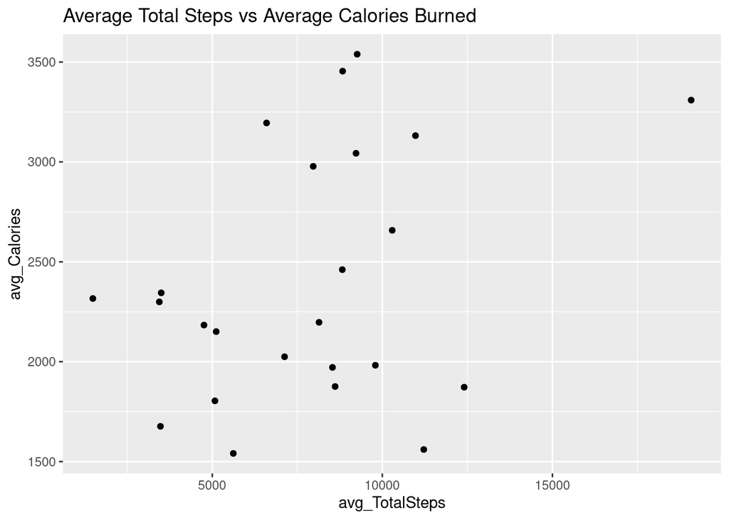

```r
ggplot(data=Activity_Sleep_Avg)+ geom_point(mapping=aes(x=avg_TotalSteps,y=avg_Calories))+labs(title="Average Total Steps vs Average Calories Burned")
```

Lets break the visualization down further than averages. The data broken down will be a bit scrambled, so I want to use a trend line in an attempt to see if there is correlation between steps and calories per user on days where intensity might have varied.

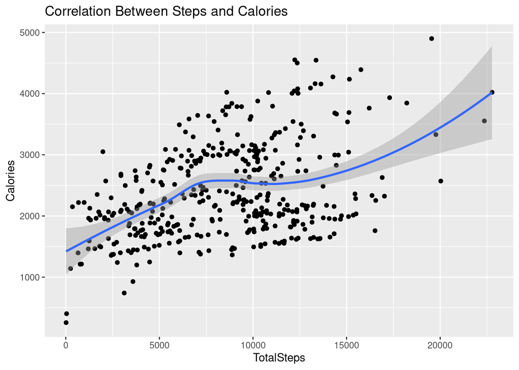

```r
ggplot(data = Daily_Activity_Sleep,mapping = aes(x=TotalSteps, y=Calories)) + geom_point() + geom_smooth() + labs(title = "Correlation Between Steps and Calories")
```

I decided to visualize the data of comparing users very active distance to calories burned. However, with some users not recording any very active distance, I will create a new data frame that omits users with 0 very active distance recorded.

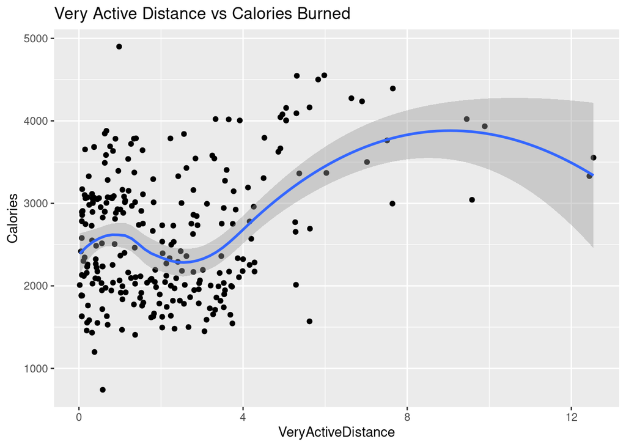

```r
VeryAcitve_data <- subset(Daily_Activity_Sleep, VeryActiveDistance != 0)
ggplot(data = VeryAcitve_data,mapping = aes (x=VeryActiveDistance, y=Calories)) + labs(title = "Very Active Distance vs Calories Burned") + geom_point() + geom_smooth()
```

I want to start by looking at the average of users total time in bed spent, versus their total time asleep.

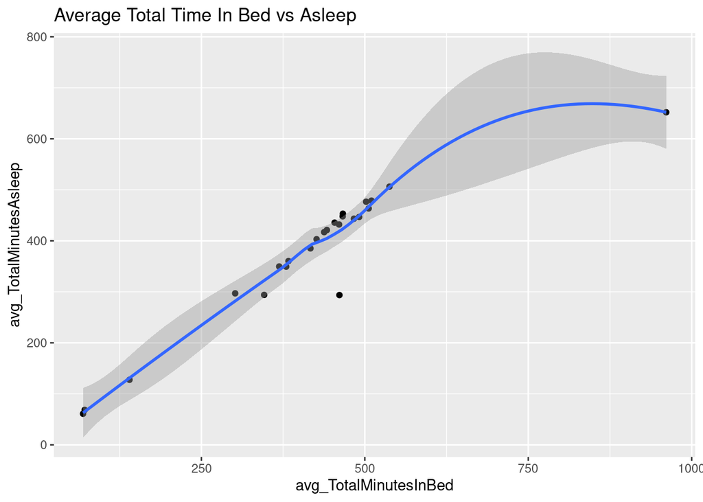

```r
ggplot(data = Activity_Sleep_Avg, mapping = aes(x = avg_TotalMinutesInBed, y = avg_TotalMinutesAsleep)) + labs(title = "Average Total Time In Bed vs Asleep") + geom_point() + geom_smooth()
```

Next, I want to compare sleep trends to calories and steps to look for any correlation

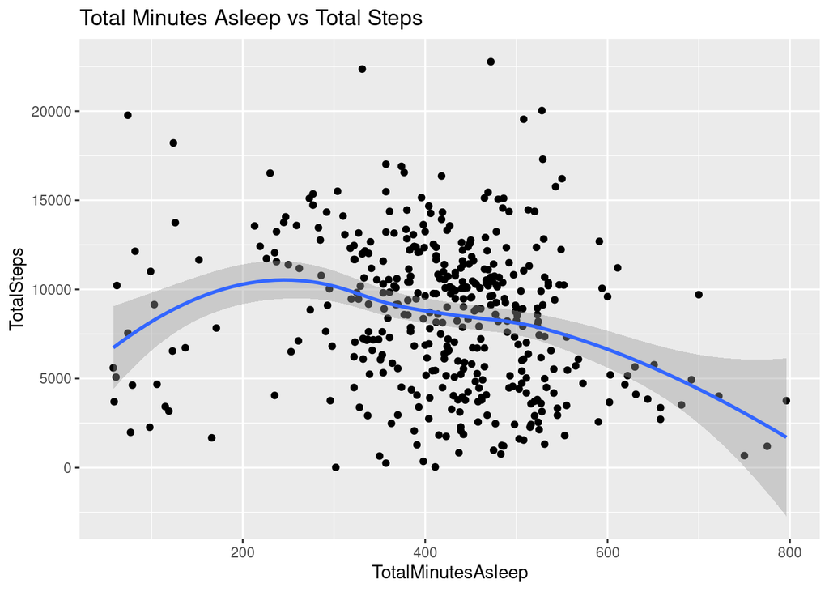

```r
ggplot(data = Daily_Activity_Sleep, mapping = aes (x = TotalMinutesAsleep, y = TotalSteps)) + labs(title = "Total Minutes Asleep vs Total Steps") + geom_point() + geom_smooth()
```

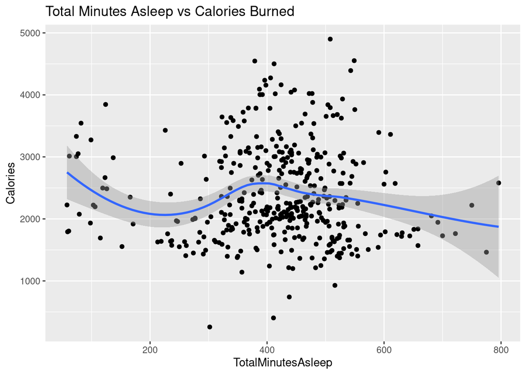

```r
ggplot(data = Daily_Activity_Sleep, mapping = aes(x = TotalMinutesAsleep, y = Calories)) + labs(title = "Total Minutes Asleep vs Calories Burned") + geom_point() + geom_smooth()
```

# Conclusion

Analyzing this data had its limitations, however gives the Bellabeat team a good idea in what to focus on with its users moving forward. The limitations of the dataset focuses around the fact that, the sample size in this dataset is relatively small, being only 30 users. However, with these 30 users, it gave me a versatile amount of data to work with; being users who range from not active, to very active, and users who get a low amount of sleep to those who get an overabundance.

# Recommendations

In reference to my report to the Bellabeat marketing team and its stakeholders, these would be my key focal points:

When researching sleep recommendations, the National Library of Medicine has an article posted around the recommended amount of sleep in adults. They recommend around 7 hours, with less than 7 hours attributing to adverse health outcomes, and over 9 hours promoting health risks as well. The Bellabeat marketing team can use this information to distribute recommendations to its users, who have particular fitness goals, that could be potentially recording not enough sleep, to the users who are getting too much sleep.

Thank you.